# Summary report for Cardiff

UKMON

2017-07-18

# Summary of activity in 2017

Cardiff operates 3 cameras.

In 2017 Cardiff has recorded 203 individual meteor observations. These observations comprise 56 sporadic meteors and 147 stream meteors. A breakdown by month is shown below.

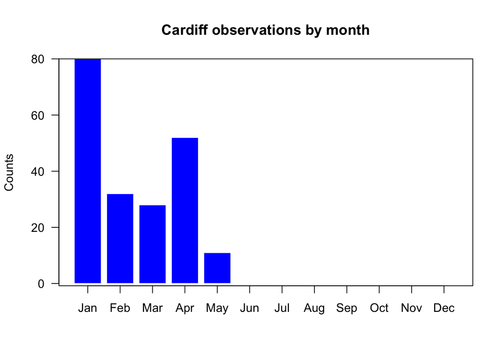

The following shows observation counts by stream for the 20 most frequent showers based on preliminary UFO ANALYSIS classifications:

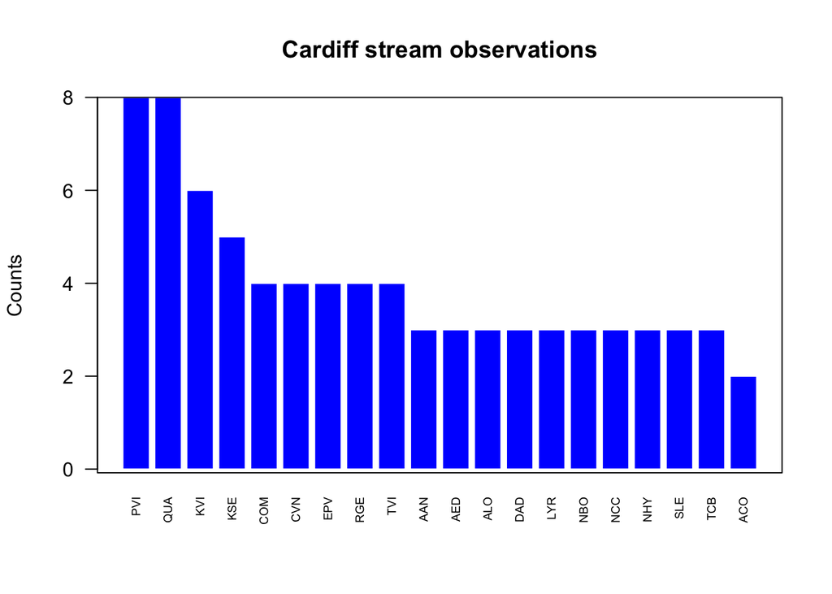

The following table shows which stations are generating matched observations with this station and the number of matches:

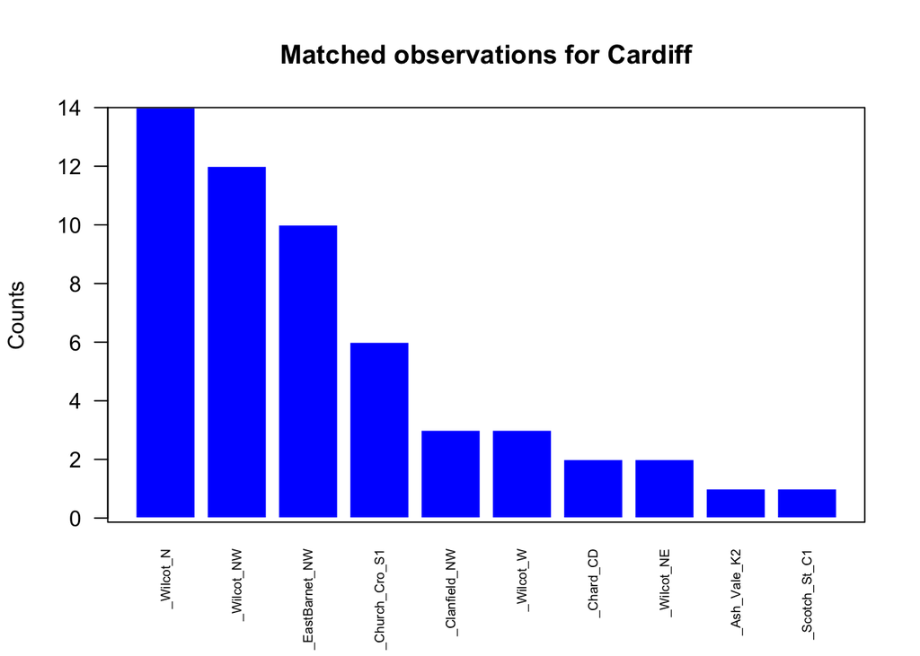

## Fireball activity

(Based on IAU definition of apparrent magnitude of -4.0 of greater)

| Datetime | Magnitude | Duration | Stream |
| --- | --- | --- | --- |
| 2017-03-24 00:05:19 | -5.3 | 1.56 | KVI |

# Observations recorded by Cardiff, 2014 to 2017

UKMON data for Cardiff covers the period from 2014 to 2017 and totals 2503 individual meteor observations. These observations comprise 720 sporadic meteors and 1783 stream meteors.

This section provides a summary of all observations by Cardiff from 2014 to 2017. A breakdown of the number of observations by year is given in the histogram below.

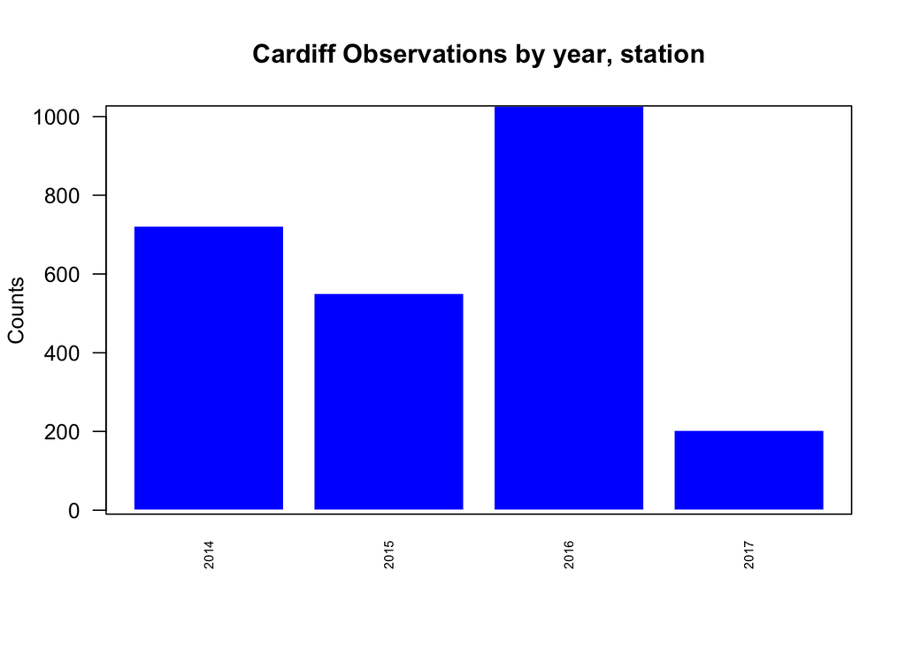

The following graph shows observation counts by stream (preliminary UFO ANALYSIS classification). A detailed breakdown by shower is given in the table at the end of this report.

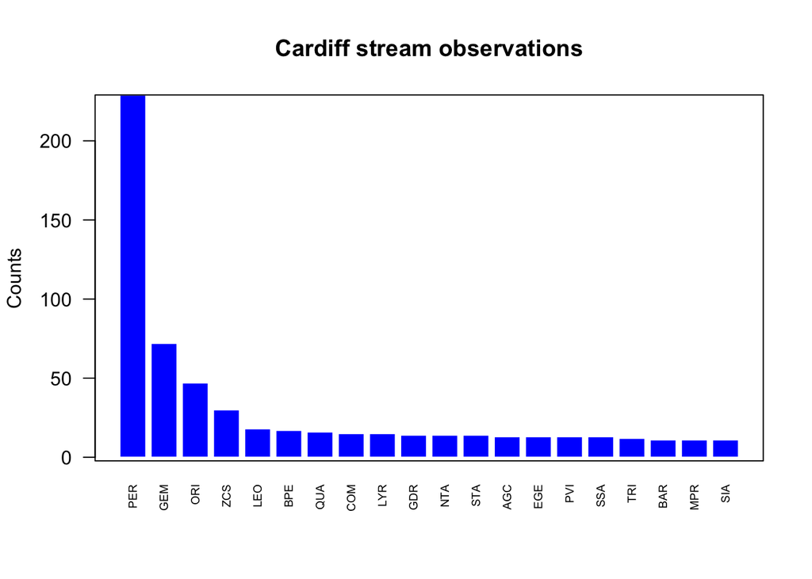

## Fireball activity

Fireballs recorded (Based on IAU definition of apparrent magnitude of -4.0 of greater)

| Datetime | Magnitude | Duration | Stream |
| --- | --- | --- | --- |
| 2015-08-13 02:51:03 | -7.2 | 0.48 | PER |
| 2016-12-22 03:18:37 | -7.2 | 0.38 | COM |
| 2016-08-11 23:33:52 | -5.9 | 0.14 | BPE |
| 2017-03-24 00:05:19 | -5.3 | 1.56 | KVI |
| 2016-08-06 03:54:48 | -4.9 | 0.50 | GER |
| 2016-08-11 23:04:01 | -4.9 | 0.60 | PER |
| 2014-08-13 02:13:04 | -4.7 | 0.64 | PER |
| 2014-08-15 03:56:22 | -4.5 | 0.44 | PER |
| 2016-07-22 00:49:15 | -4.5 | 1.14 | CAP |
| 2016-08-13 03:40:28 | -4.5 | 0.30 | AIC |
| 2014-11-04 22:44:02 | -4.4 | 1.30 | OEE |
| 2016-03-30 01:46:48 | -4.4 | 0.42 | AAL |
| 2014-12-01 02:58:58 | -4.3 | 0.56 | SPO |
| 2015-08-08 00:53:25 | -4.3 | 0.82 | PER |
| 2016-08-16 23:29:09 | -4.3 | 1.08 | PER |
| 2014-09-09 03:04:02 | -4.1 | 0.66 | SPO |
| 2014-08-13 00:41:10 | -4.0 | 0.56 | MPR |
| 2014-09-16 21:38:21 | -4.0 | 1.22 | SPO |
| 2014-10-24 06:03:32 | -4.0 | 0.12 | SPO |
| 2015-08-07 01:13:31 | -4.0 | 0.66 | PER |
| 2016-01-04 22:14:29 | -4.0 | 0.86 | COM |
| 2016-08-04 21:31:39 | -4.0 | 1.14 | ZCS |
| 2016-08-12 00:27:11 | -4.0 | 0.88 | PER |

The following table shows which stations are generating matched observations with this station and the number of matches:

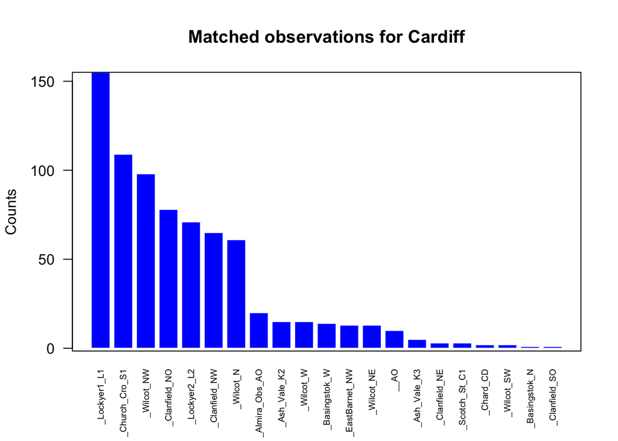

# Detailed counts (including sporadics)

| Shower | Counts |
| --- | --- |
| SPO | 720 |
| PER | 229 |
| GEM | 72 |
| ORI | 47 |
| ZCS | 30 |
| LEO | 18 |
| BPE | 17 |
| QUA | 16 |
| COM | 15 |
| LYR | 15 |
| GDR | 14 |
| NTA | 14 |
| STA | 14 |
| AGC | 13 |
| EGE | 13 |
| PVI | 13 |
| SSA | 13 |
| TRI | 12 |
| BAR | 11 |
| MPR | 11 |
| SIA | 11 |
| XAU | 11 |
| ZTA | 11 |
| ATR | 10 |
| KCG | 10 |
| NUE | 10 |
| SPE | 10 |
| ANA | 9 |
| AUR | 9 |
| BAU | 9 |

[output cut: 321 more lines]